# Analysis of Swaptions

## High level analysis of data from DTCC

```r
start_date <- "2022-03-01"
end.date <- "2022-03-31"
bizdays <- bizdays::bizseq(start_date, end.date, "weekends")
data <- DownloadFromDTCC(bizdays)
```

```r
swaptions <- data |>
  dplyr::filter(grepl("Swaption", `Product ID`))

n.total <- nrow(swaptions)
```

The number of swaptions contracts traded in March was 36701 representing 7.39 of all the trades reported to DTCC.

The following table distinguishese between NEW, CANCEL and CORRECT trades

```r
swaptions |>
  dplyr::count(Action)
```

```
## # A tibble: 3 × 2
##   Action      n
##   <chr>   <int>
## 1 CANCEL  10927
## 2 CORRECT  9836
## 3 NEW     15938
```

Let’s focus only on the new ones and see the different trade types

```r
swaptions <- swaptions |>
  dplyr::filter(grepl("NEW", Action))

swaptions |>
  dplyr::count(`Transaction Type`)
```

```
## # A tibble: 4 × 2
##   `Transaction Type`     n
##   <chr>              <int>
## 1 Amendment           1176
## 2 Novation            1201
## 3 Termination         4662
## 4 Trade               8899
```

Hence, out of 36701 contracts, only 8899 are actual new trades. We can now analyse the currencies of the new trades:

```r
swaptions |>
  dplyr::count(`Notional Currency 1`) |>
  dplyr::arrange(dplyr::desc(n))
```

```
## # A tibble: 12 × 2
##    `Notional Currency 1`     n
##    <chr>                 <int>
##  1 USD                    5035
##  2 EUR                    2676
##  3 GBP                     503
##  4 JPY                     459
##  5 AUD                     130
##  6 KRW                      49
##  7 TWD                      20
##  8 PLN                      13
##  9 ZAR                       6
## 10 CAD                       4
## 11 MXN                       3
## 12 CZK                       1
```

## Analysis uf USD Swaptions

```r
swaptions |>
  dplyr::count(`Option Style`)
```

```
## # A tibble: 2 × 2
##   `Option Style`     n
##   <chr>          <int>
## 1 BM               145
## 2 EU              4890
```

The vast majority is European with a few Bermudan ones.

The type of the swaption (Call/Put) should be in the field *Option Type* but that field is intelligible as it is reported:

```r
swaptions |>
  dplyr::count(`Option Type`)
```

```
## # A tibble: 4 × 2
##   `Option Type`     n
##   <chr>         <int>
## 1 C-                2
## 2 D-             1412
## 3 PF             2088
## 4 RF             1533
```

**We can possibly try and contact DTCC to get the information on what these acronyms mean?**

Let’s now look at the maturities and tenors using the agreed convention

```r
trades.cube <- swaptions |>
  dplyr::mutate(
    Maturity = round(as.numeric((`Effective Date` - `Event Timestamp`)/365),0),
    Tenor = round(as.numeric((`Expiration Date` - `Effective Date`)/365),0)) |>
  dplyr::group_by(Maturity, Tenor) |>
  dplyr::summarise(Notional = sum(`Notional Amount 1`),
                   Trades = dplyr::n())
```

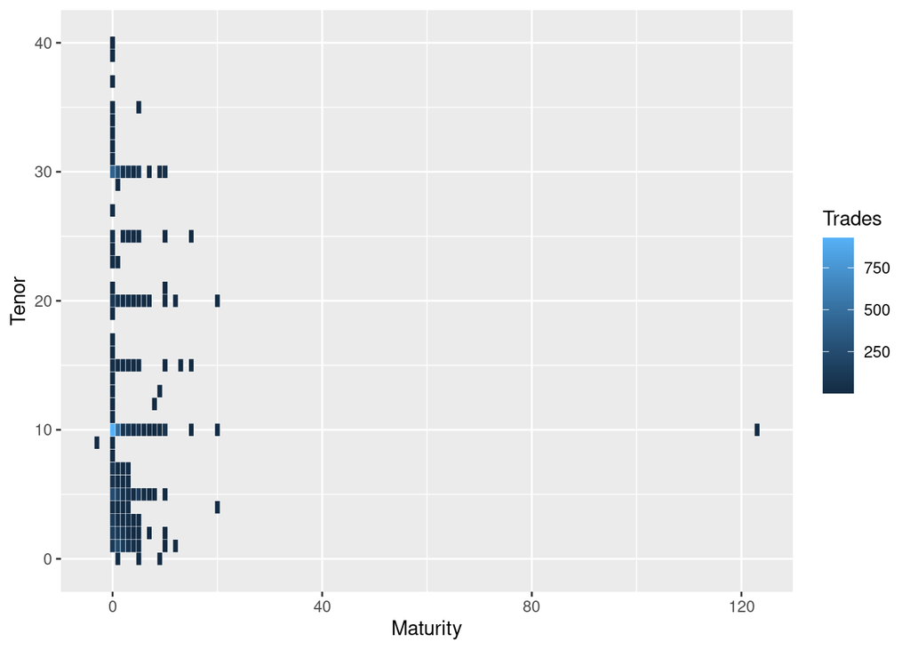

```r
trades.cube |>
  ggplot(aes(x = Maturity, y = Tenor)) +
  geom_tile(aes(fill = Trades), colour = "white")
```

- a 120+ years Maturity contract looks like an error/outlier we can remove
- a negative maturity swaption doesn’t look reasonable
- all the contracts with Maturity = 0 have a maturity which is less than 6 months

Let’s remove the outlier and zoom on the 1-20 years maturity range. The number in the tile represents the number of trades for that specific pair of maturity and tenor.

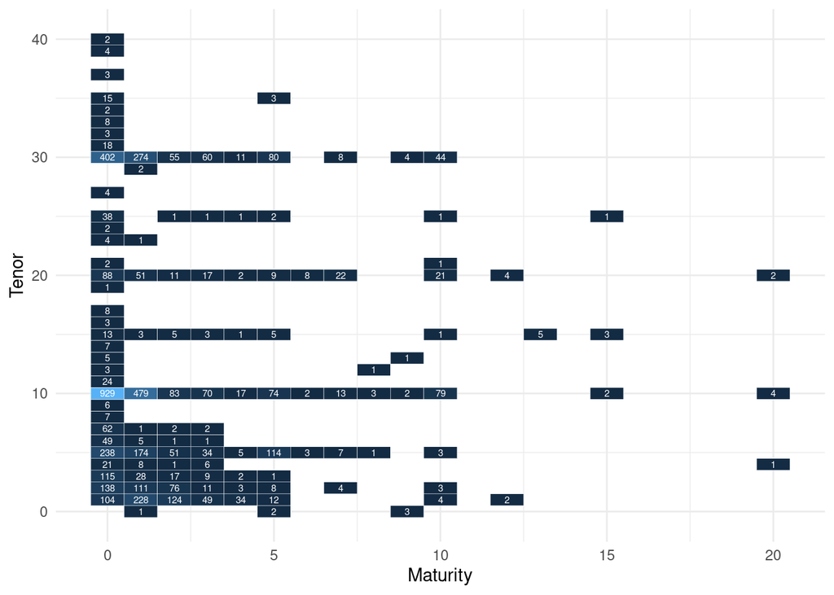

```r
trades.cube |>
  dplyr::filter(Maturity <= 20, Maturity >= 0, Tenor >= 0) |>
  ggplot(aes(x = Maturity, y = Tenor)) +
  geom_tile(aes(fill = Trades), colour = "white") +
  geom_text(aes(label = Trades), size = 2, colour = "white") +
  theme_minimal() +
  theme(legend.position="none")
```

We can notice some clusters of trades, but we can further focus on the points on the cube that have at least 20 trades performed in March.

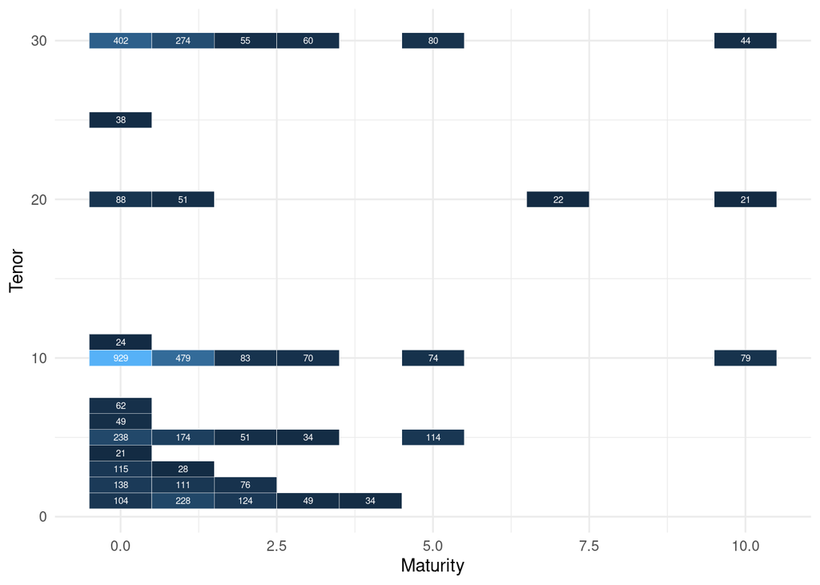

```r
trades.cube |>
  dplyr::filter(Maturity <= 20, Maturity >= 0, Tenor >= 0, Trades > 20) |>
  ggplot(aes(x = Maturity, y = Tenor)) +
  geom_tile(aes(fill = Trades), colour = "white") +
  geom_text(aes(label = Trades), size = 2, colour = "white") +
  theme_minimal() +
  theme(legend.position="none")
```

So most of the trades:

- Have a maturity lower than 5 years, 7 or 10 years
- Have tenors mostly below 10 years or 20 and 30 years